# Essence of Calculus

# Setup

## Load libraries

```r
suppressPackageStartupMessages( {
  library(RColorBrewer)
} )
```

## Color palettes

```r
pal <- brewer.pal(11, name="Spectral")
cl1 <- "red4"
cl2 <- "peru"
```

# Fundamental theorem of calculus

If $f(x)$ is continuous over interval $[a,b]$, and $F(x)$ is defined as $F(x)=\int_a^x f(t)dt$, then $F'(x)=f(x)$ over $[a,b]$.

$dx=\Delta x \rightarrow 0$

$\dfrac{d}{dx} \int_a^xf(t)dt=f(x)$

$\int_a^b f(x)dx=F(B)-F(A)$ where $F(X)=\int f(x)$

# Derivatives

## General form of a derivative

$\dfrac{ds}{dt}(s)=\dfrac{s(t+dt)-s(t)}{dt}$ as $dt \rightarrow 0$, i.e. we are taking tinier and tinier steps to be able to approximate an “instantaneous rate”. Posing the problem as a limit prevents us from stumbling into paradoxes due to the seemingly counterintuitive phrase “instantaneous rate” since a rate by definition requires a rate of change between two different points.

## Rules

### Constant rule

$\dfrac{d}{dx}(c)=0$

### Constant multiple rule

$\dfrac{d}{dx}(cf(x))=cf'(x)$

### Power rule

$\dfrac{d}{dx}(x^n)=nx^{x-1}$

### Sum rule

$\dfrac{d}{dx}(f(x)+g(x))=f'(x)+g'(x)$

### Product rule

“Left d(Right) + Right d(Left)”

$\dfrac{d}{dx}(f(x)g(x))=f(x)g'(x) + f'(x)g(x)$

### Quotient rule

$\dfrac{d}{dx}[\dfrac{f(x)}{g(x)}]=\dfrac{g(x)f'(x)-f(x)g'(x)}{[g'(x)]^2}$

### Chain rule

$\dfrac{d}{dx}(g(h(x))=\dfrac{dg}{dh}\dfrac{dh}{dx}=\dfrac{dg}{dx}$

## Exponentials and Euler’s number

Remember this fundamental rule of exponents…

$2^{a+b}=2^a2^b$

Let’s say we have a population that is exponentially growing with the doubling function $M(t)=2^t$.

Then,

$\dfrac{dM}{dt}(t)=\dfrac{2^{t+dt}-2^t}{dt}=\dfrac{2^t2^{dt}-2^t}{dt}=2^t[\dfrac{2^{dt}-1}{dt}]$. Since $dt \rightarrow 0$, we can plug in smaller and smaller values of $dt$ into the second part of the equation $\dfrac{2^{dt}-1}{dt}$ and we will see that we converge at a constant…

```r
dt <- 0.01
(2^dt-1)/dt
```

```
## [1] 0.695555
```

```r
dt <- 1e-4
(2^dt-1)/dt
```

```
## [1] 0.6931712
```

```r
dt <- 1e-6
(2^dt-1)/dt
```

```
## [1] 0.6931474
```

```r
dt <- 1e-10
log(2, exp(1))
```

```
## [1] 0.6931472
```

```r
( round( (2^dt-1)/dt, 5) )==round( log(2, exp(1)), 5 )
```

```
## [1] TRUE
```

```r
0.6931478*3
```

```
## [1] 2.079443
```

```r
2^3
```

```
## [1] 8
```

```r
dt <- 0.01
(8^dt-1)/dt
```

```
## [1] 2.101213
```

```r
dt <- 1e-4
(8^dt-1)/dt
```

```
## [1] 2.079658
```

```r
dt <- 1e-6
(8^dt-1)/dt
```

```
## [1] 2.079444
```

```r
dt <- 1e-10
(8^dt-1)/dt
```

```
## [1] 2.079441
```

So this is telling us that the derivative of $2^t$ is just itself times a constant, i.e. $\dfrac{d(2^t)}{dt}=c2^t$.

Q: Is there a base where that proportionality constant is 1? A: Yes! Euler’s number

```r
e <- exp(1)
dt <- 0.01
(e^dt-1)/dt
```

```
## [1] 1.005017
```

```r
dt <- 1e-4
(e^dt-1)/dt
```

```
## [1] 1.00005
```

```r
dt <- 1e-6
(e^dt-1)/dt
```

```
## [1] 1
```

```r
dt <- 1e-10
(e^dt-1)/dt
```

```
## [1] 1
```

This is what defines the number e. The fact that, when raised to an independent variable, it is a derivative of itself.

$\dfrac{d(e^x)}{dx}=e^x$, or, more generally…

$\dfrac{d(e^{cx})}{dx}=ce^{cx}$

It’s a bit like asking “Why does pi happen to be the ratio of the circumference of a circle to its diameter?” This is circular, because this is what *defines* this value.

All exponential functions are proportional to their own derivative, but e alone is equal to its own derivative.

$2=e^{ln(2)}$ (by definition), i.e. `ln(x)` is the inverse of `e^x`. $2^t=e^{ln(2)t}$

$\dfrac{2^x-1}{x}=ln(2)$ for small $x \rightarrow 0$.

SO, in conclusion, we have:

$\dfrac{d(2^x)}{dx}=2^xln(2)$

Try to write anything in exponential form with $e$ as the base to make the intuition easier!

$a^x=e^{cx}$.

E.g. $\dfrac{d(\Delta T)}{dt}=-k \Delta T$ so $\Delta T(t)=e^{kt}$, i.e. the rate of change in temperature is proportional to the difference in temperature itself. This is a very natural concept.

## Implicit derivatives

Sometimes functions do not have separate independent and dependent variables and are rather on the same side of the equation, i.e. interdependent in a certain relation.

### E.g. $x^2 + y^2 = 5^2$.

To calculate the derivative, you derive both sides of the equation, giving

$2xdx + 2ydy = 0$

$\dfrac{dy}{dx}=-\dfrac{x}{y}$

### E.g. $sin(x)y^2=x$

$sin(x)y^2=x$. Derive both sides using “Left d-right plus right d-left”…

$sin(x)2ydy+y^2cos(x)dx=dx$

### E.g. $y=ln(x)$

Remember, $ln(x)$ is the inverse function of $e^x$.

$y=ln(x)$

$e^y=x$

$e^ydy=dx$

$\dfrac{dy}{dx}=\dfrac{1}{e^y}=\dfrac{1}{x}$.

# Limits

## Formal definition of derivatives

General form: $\dfrac{ds}{dt}(s)=\dfrac{s(t+dt)-s(t)}{dt}$ as $dt \rightarrow 0$

$\dfrac{df}{dx}(2)=\lim_{h \rightarrow 0} \dfrac{f(2+h)-f(2)}{h}$

## $(\epsilon, \delta)$ definition of limits

Glimpse into *real analysis*. Idea is that when a limit exists you can make the output range as small as you want, but when the limit does *not* exist, that *output* range can*not* get smaller than some particular value (e.g. for discontinuous functions) no matter how much you shrink the *input* range.

What it means for the limit to *exist* is that you can always find a range of inputs around our limiting input some distance **delta** from 0, such that any *input* within a distance *delta* of 0 corresponds to an output within a distance **epsilon** of 12 (or other number on right of equation).

## L’Hôpital’s rule (irl Bernoulli’s rule)

$lim_{x \rightarrow a}\dfrac{f(x)}{g(x)}=\dfrac{ \dfrac{df}{dx}(a)dx}{\dfrac{dg}{dx}(a)dx}=\dfrac{ \dfrac{df}{dx}(a)}{\dfrac{dg}{dx}(a)}$

### E.g. Dampened oscillation $\dfrac{sin\pi x}{x^2-1}$

At $x=(-1,1)$ denominator is 0.

Derivative of $sin(\pi x)$:

$d(sin(\pi x))=\pi cos(\pi x)dx$ and at $x=1$ we have

$\pi cos(\pi)dx=-\pi dx$.

Similarly for $d(x^2-1)=2xdx=2dx$. Plugging it into the formal derivative equation, we have,

$lim_{x \rightarrow 1}\dfrac{sin\pi x}{x^2-1} \approx \dfrac{-\pi dx}{2dx}\approx \dfrac{-\pi }{2}$

```r
x <- seq(-2*pi, 2*pi, 0.1)
y <- sin(pi*x)/(x^2-1)

x_illeg <- c(-1.000000001, 1.000000001)
y_illeg <- sin(pi*x_illeg)/(x_illeg^2-1)
round(y_illeg[2], 6)==round(-pi/2, 6)
```

```
## [1] TRUE
```

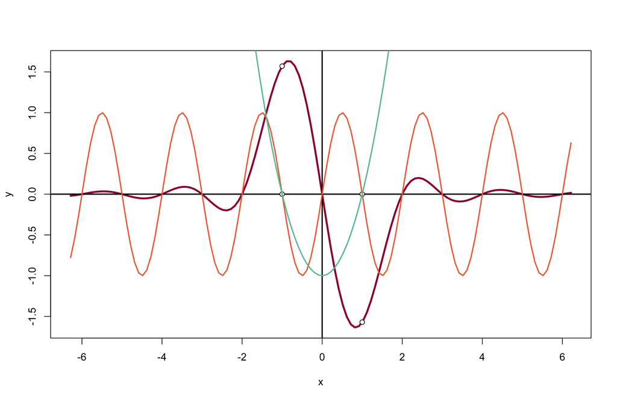

```r
plot(x, y, type="l", col=pal[1], lwd=3)
abline(h=0, v=0, lwd=2)
points(rep(x_illeg,2), c(y_illeg,0,0), pch=21, bg="white")
lines(x, sin(pi*x), col=pal[3], lwd=2)
lines(x, x^2-1, col=pal[9], lwd=2)
```

## Relationship of area and slope

Slope = $\dfrac{\int_0^\pi sin(x)dx}{\pi}=\dfrac{-cos(x)(-cos(0))}{\pi}=\dfrac{2}{\pi}$

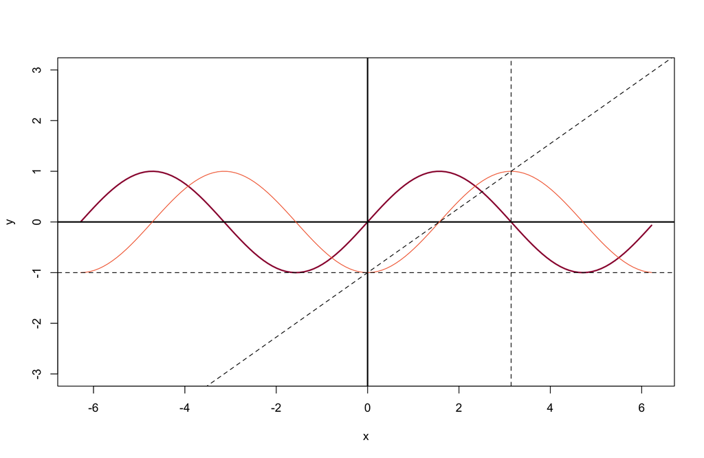

```r
x <- seq(-2*pi, 2*pi, 0.1)
y <- sin(x)
y1 <- -cos(x)
y2 <- 2*x/pi

plot(x, y, type="l", col=pal[1], lwd=2, ylim=c(-3,3))
abline(h=0, v=0, lwd=2)
lines(x, y1, col=pal[3])
abline(v=pi, lty=2)
abline(h=-1, lty=2)
abline(a=-1, b=2/pi, lty=2)
```

Why does the slope represent an *average* value of x in that region?

$Average=\dfrac{\int_a^b f(x) dx}{b-a}=\dfrac{F(b)-F(a)}{b-a}$

# Taylor Expansions

Taylor expansions allow us to approximate solutions/functions when $x\rightarrow 0$. Largely about taking non-polynomial functions and finding polynomials that approximate them near some angle. Why do this? Polynomials are *much* easier to deal with than other functions, such as cosine, etc. They are easier to compute derivatives, integrals.

## General form

At $x-0$:

$P(x)=f(0) + \dfrac{df}{dx}(0)\dfrac{x^1}{1!} + \dfrac{d^2f}{dx^2}(0)\dfrac{x^2}{2!} + \dfrac{d^3f}{dx^3}(0)\dfrac{x^3}{3!} + \dfrac{d^4f}{dx^4}(0)\dfrac{x^4}{4!} + ...$

At any point $x=a$:

$P(x)=f(a) + \dfrac{df}{dx}(a)\dfrac{(x-a)^1}{1!} + \dfrac{d^2f}{dx^2}(a)\dfrac{(x-a)^2}{2!} + \dfrac{d^3f}{dx^3}(a)\dfrac{(x-a)^3}{3!} + \dfrac{d^4f}{dx^4}(a)\dfrac{(x-a)^4}{4!} + ...$

**Definitions**:

- **Taylor series**: the infinite sum, including *all* polynomial terms
- **Convergent series**: converges to the actual solution of the original function
- **Divergent series**: after reaching a certain threshold, will never converge and rather overshoot back and forth
  - **Radius of convergence**: the aforementioned threshold before which the series converges but after which the series diverges

## Example: $e^x$

The easiest example of a Taylor series is $e^x$, since $\dfrac{d(e^x)}{dx}=e^x$, i.e. its derivative is the same as the original function! So using the general form above…

$P(e^x)=1 + x + \dfrac{1}{2}x^2 + \dfrac{1}{6}x^3 + \dfrac{1}{24}x^4 + ...$

## Example: $e^{-x^2}$

Will need the *chain rule* for step (2)…

$\dfrac{d}{dx}(g(h(x))=\dfrac{dg}{dh}\dfrac{dh}{dx}=\dfrac{dg}{dx}$

Steps:

$P(e^{-x^2})=1 + 0x - 2(\dfrac{1}{2})x^2 + 0x^3 + \dfrac{1}{2}x^4 + ...$

```r
## first derivative
D( expression( e^(-x^2) ), 'x') # -(e^(-x^2) * (log(e) * (2 * x)))
```

```
## -(e^(-x^2) * (log(e) * (2 * x)))
```

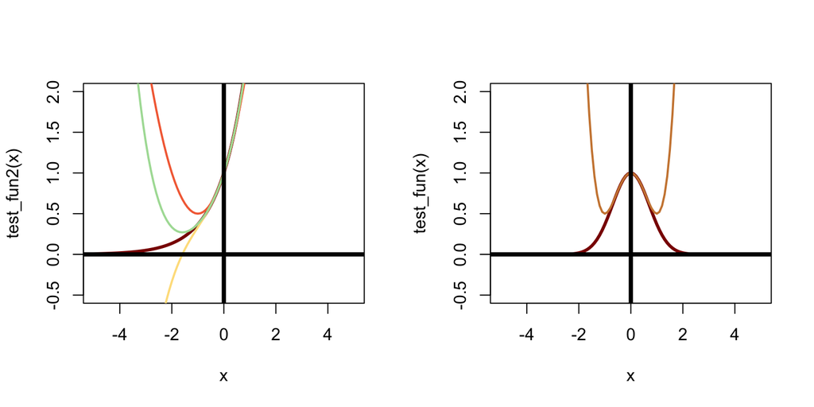

```r
e <- exp(1)

test_fun <- function(x) {
  e <- exp(1)
  y <- e^(-x^2)
  return(y)
}

tay_fun <- function(x) {
  e <- exp(1)
  y <- 1-(x^2)+0.5*x^4
  return(y)
}

test_fun2 <- function(x) {
  e <- exp(1)
  y <- e^x
  return(y)
}

tay_fun2 <- function(x) {
  e <- exp(1)
  y <- 1+x+(0.5*x^2)
  return(y)
}

tay_fun2_2 <- function(x) {
  e <- exp(1)
  y <- 1+x+(0.5*x^2)+((1/6)*(x^3))
  return(y)
}

tay_fun2_3 <- function(x) {
  e <- exp(1)
  y <- 1+x+(0.5*x^2)+((1/6)*(x^3))+((1/24)*(x^4))
  return(y)
}

x <- seq(-5, 5, by=0.1)

par(mfrow=c(1,2))

plot(x, test_fun2(x), type="l", col=cl1, lwd=3, ylim=c(-0.5,2))
lines(x, tay_fun2(x), col=pal[3], lwd=2)
lines(x, tay_fun2_2(x), col=pal[5], lwd=2)
lines(x, tay_fun2_3(x), col=pal[8], lwd=2)
abline(h=0, v=0, lwd=4)

plot(x, test_fun(x), type="l", col=cl1, lwd=3, ylim=c(-0.5,2))
lines(x, tay_fun(x), col=cl2, lwd=2)
abline(h=0, v=0, lwd=4)
```

## Example: $y=cosx$

Cosine form:

$cos(x)=1$ at $x=0$. Derivative is $\dfrac{d(cos)}{dx}(0)=-sin(0)=0$.

Polynomial form:

Generally, $P(x)=c_0 + c_1x + c_2x^2$. We know that $cos(0)=1$; therefore, $c_0$, giving us $P(x)=1 + c_1x + c_2x^2$. Deriving that expression, we get $\dfrac{dP}{dx}(0)=c_1 + 2c_20=c_1$.

$c_0=1$ $c_1=0$

Now we have $P(x)=1 + 0x + c_2x^2$ and are free to change $x_2$ so we can take advantage of the fact that the derivative $-sinx$ curves downward upon moving away from 0, i.e. it has a negative second derivative. Even though the rate of change is 0 at that point, the rate of change itself is decreasing at that point. Making sure that the second derivatives match will ensure that the original curve and polynomial curve at the same rate.

$\dfrac{d^2P}{dx^2}(x)=2c_2=-1$ $c_2=-1/2$

Steps:

1. *Original*: $cos(x) \xrightarrow {x \rightarrow 0}1$; *polynomial*: $P(x)=1 +...$
- 1st term is 1 b/c cos(0) is 1
- 2nd term is 0 b/c -sin(0) is 0
2. *1st derivative*: $\dfrac{d(cosx)}{dx}=-sinx=-sin0=0$ $P(x)=1 + 0c...$
3. *2nd derivative*: $-sin(0)=0$; *polynomial*: $\dfrac{dP}{dx}(x)=0 + 0x + 2c_2x$
4. *2nd derivative*: $-cos(0)=-1$; *polynomial*: $\dfrac{d^2P}{dx^2}(x)=2c_2$

**Polynomial**: $P(x)=1 - \dfrac{1}{2}x^2$

```r
## first and second derivatives
D( expression( cos(x) ), "x" ) # -sinx
```

```
## -sin(x)
```

```r
D( expression( -sin(x) ), "x" ) # -cosx
```

```
## -cos(x)
```

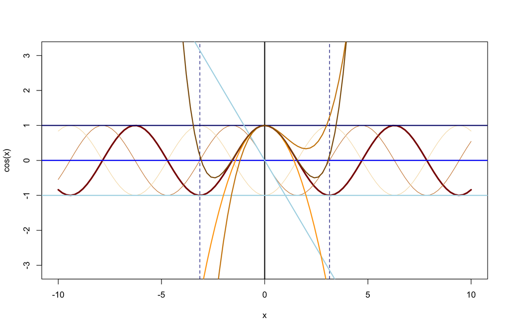

```r
## set colors
pal <- brewer.pal(8, name="Spectral")
cl1 <- "red4"
cl2 <- "peru"

## initiate x
x <- seq(-10,10,by=0.2)

## plot
plot(x, cos(x), type="l", col=cl1, lwd=3, ylim=c(-pi,pi))
lines(x, -sin(x), col=cl2)
lines(x, -cos(x), col="wheat")
abline(h=0, v=0, lwd=2)
abline(v=pi, col="navy", lty=2)
abline(v=-pi, col="navy", lty=2)

# original solution is 1
abline(h=1, col="navy", lwd=2)

# 1st derivative solution is 0
abline(h=0, col="blue", lwd=2)

# 2nd derivative solution is -1
abline(h=-1, col="lightblue", lwd=2)
abline(a=0, b=-1, col="lightblue", lwd=2)

# taylor expansion
lines(x, (1-(0.5*x^2)), col="orange", lwd=2)
lines(x, (1-(0.5*x^2)+(1/6)*x^3), col="orange3", lwd=2) # add 3rd term, 1/6 b/c 3*2*1=6
lines(x, (1-(0.5*x^2)+(1/24)*x^4), col="orange4", lwd=2) # add 4th term, 1/24 b/c 4*3*2*1=24
```

Now let’s try with brewer palette colors…

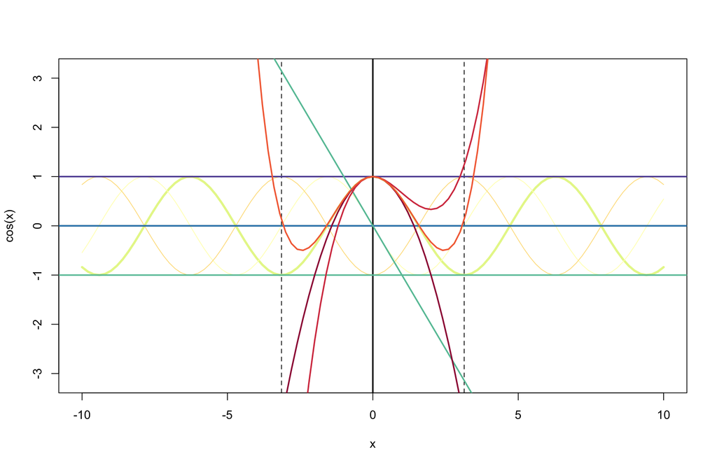

```r
## plot
n <- 11
pal <- brewer.pal(11, name="Spectral")
plot(x, cos(x), type="l", col=pal[[7]], lwd=3, ylim=c(-pi,pi))
lines(x, -sin(x), col=pal[[6]])
lines(x, -cos(x), col=pal[[5]])
abline(h=0, v=0, lwd=2)
abline(v=pi, lty=2)
abline(v=-pi, lty=2)

# original solution is 1
abline(h=1, col=pal[[n]], lwd=2)

# 1st derivative solution is 0
abline(h=0, col=pal[[n-1]], lwd=2)

# 2nd derivative solution is -1
abline(h=-1, col=pal[[n-2]], lwd=2)
abline(a=0, b=-1, col=pal[[n-2]], lwd=2)

# taylor expansion
lines(x, (1-(0.5*x^2)), col=pal[[1]], lwd=2)
lines(x, (1-(0.5*x^2)+(1/6)*x^3), col=pal[[2]], lwd=2) # add 3rd term, 1/6 b/c 3*2*1=6
lines(x, (1-(0.5*x^2)+(1/24)*x^4), col=pal[[3]], lwd=2) # add 4th term, 1/24 b/c 4*3*2*1=24
```

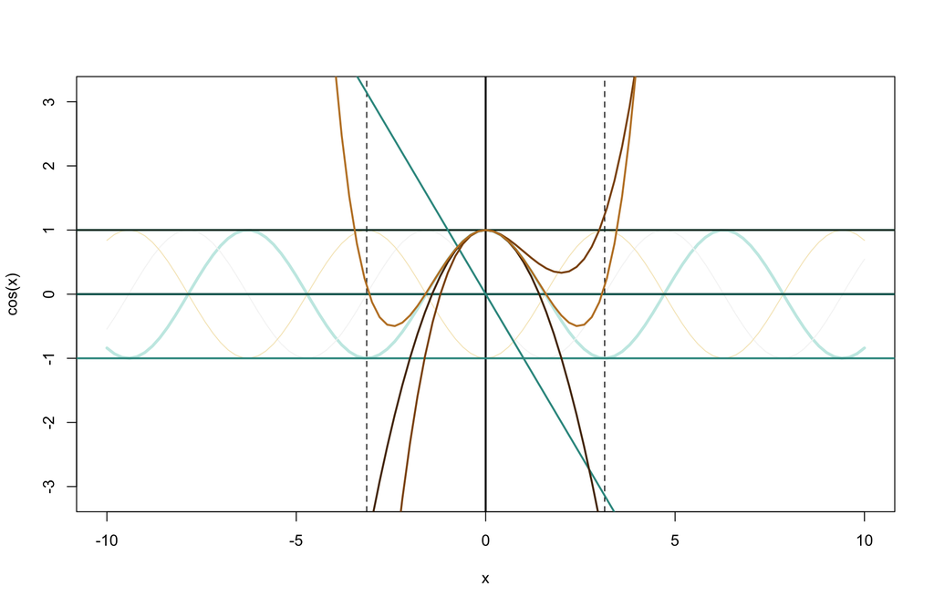

```r
## plot
n <- 11
pal <- brewer.pal(n, name="BrBG")
plot(x, cos(x), type="l", col=pal[[7]], lwd=3, ylim=c(-pi,pi))
lines(x, -sin(x), col=pal[[6]])
lines(x, -cos(x), col=pal[[5]])
abline(h=0, v=0, lwd=2)
abline(v=pi, lty=2)
abline(v=-pi, lty=2)

# original solution is 1
abline(h=1, col=pal[[n]], lwd=2)

# 1st derivative solution is 0
abline(h=0, col=pal[[n-1]], lwd=2)

# 2nd derivative solution is -1
abline(h=-1, col=pal[[n-2]], lwd=2)
abline(a=0, b=-1, col=pal[[n-2]], lwd=2)

# taylor expansion
lines(x, (1-(0.5*x^2)), col=pal[[1]], lwd=2)
lines(x, (1-(0.5*x^2)+(1/6)*x^3), col=pal[[2]], lwd=2) # add 3rd term, 1/6 b/c 3*2*1=6
lines(x, (1-(0.5*x^2)+(1/24)*x^4), col=pal[[3]], lwd=2) # add 4th term, 1/24 b/c 4*3*2*1=24
```

So how good is this approximation? Let’s try it out for, say, 0.1…

```r
cos(0.1)
```

```
## [1] 0.9950042
```

```r
1-0.5*(0.1^2)
```

```
## [1] 0.995
```

Pretty damn close!

# Golden ratio

$x_{n+1}=1+\dfrac{1}{x_n}$

```r
rand_nums <- rnorm(20, mean=0, sd=50)

n_iter <- 20
mat <- matrix(data=NA, nrow = length(rand_nums), ncol=n_iter)
for(i in 1:length(rand_nums)) {
  x <- rand_nums[i]
  for(j in 1:n_iter) {
    ans_tmp <- 1+(1/x)
    mat[i,j] <- ans_tmp
    x <- ans_tmp
  }
}

mat
```

```
##            [,1]     [,2]     [,3]     [,4]     [,5]     [,6]     [,7]     [,8]
##  [1,] 0.9642560 2.037069 1.490901 1.670735 1.598539 1.625571 1.615168 1.619131
##  [2,] 0.9570856 2.044839 1.489036 1.671575 1.598238 1.625689 1.615124 1.619148
##  [3,] 1.0449119 1.957019 1.510981 1.661822 1.601749 1.624317 1.615643 1.618949
##  [4,] 1.0325043 1.968519 1.507996 1.663132 1.601275 1.624502 1.615573 1.618975
##  [5,] 0.9788677 2.021589 1.494661 1.669048 1.599144 1.625335 1.615258 1.619096
##  [6,] 1.0305862 1.970322 1.507531 1.663336 1.601201 1.624531 1.615562 1.618980
##  [7,] 0.9712532 2.029598 1.492708 1.669923 1.598830 1.625457 1.615211 1.619114
##  [8,] 1.6630502 1.601305 1.624491 1.615578 1.618974 1.617675 1.618171 1.617982
##  [9,] 1.0477731 1.954405 1.511665 1.661522 1.601858 1.624275 1.615659 1.618942
## [10,] 1.0580856 1.945103 1.514112 1.660453 1.602245 1.624124 1.615716 1.618920
## [11,] 1.0478972 1.954292 1.511694 1.661509 1.601862 1.624273 1.615660 1.618942
## [12,] 0.9861898 2.014004 1.496523 1.668215 1.599443 1.625218 1.615302 1.619079
## [13,] 0.9195680 2.087467 1.479049 1.676110 1.596620 1.626323 1.614884 1.619240
## [14,] 0.9758025 2.024798 1.493877 1.669399 1.599018 1.625384 1.615239 1.619103
```

[output cut: 48 more lines]

The golden ratio is the **fixed point**, $\phi$! No matter where you start, you end up there.

## Cobbweb plots

Ref.: https://bayesianbiologist.com/2012/07/13/dynamical-systems-mapping-chaos-with-r/

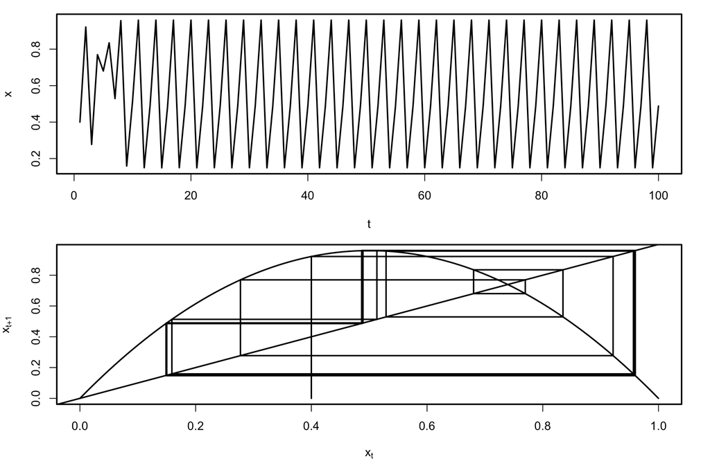

```r
q_map<-function(r=1,x_o=runif(1,0,1),N=100,burn_in=0,...)
{
  par(mfrow=c(2,1),mar=c(4,4,1,2),lwd=2)
  ############# Trace #############
  x<-array(dim=N)
  x[1]<-x_o
  for(i in 2:N)
    x[i]<-r*x[i-1]*(1-x[i-1])

  plot(x[(burn_in+1):N],type='l',xlab='t',ylab='x',...)
  #################################

  ##########  Quadradic Map ########
  x<-seq(from=0,to=1,length.out=100)
  x_np1<-array(dim=100)
  for(i in 1:length(x))
    x_np1[i]<-r*x[i]*(1-x[i])

  plot(x,x_np1,type='l',xlab=expression(x[t]),ylab=expression(x[t+1]))
  abline(0,1)

  start=x_o
  vert=FALSE
  lines(x=c(start,start),y=c(0,r*start*(1-start)) )
  for(i in 1:(2*N))
  {
    if(vert)
    {
      lines(x=c(start,start),y=c(start,r*start*(1-start)) )
      vert=FALSE
    }
    else
    {
      lines(x=c(start,
                r*start*(1-start)),
            y=c(r*start*(1-start),
                r*start*(1-start)) )
      vert=TRUE
      start=r*start*(1-start)
    }
  }
  #################################
}

q_map(r=3.84,x_o=0.4)
```

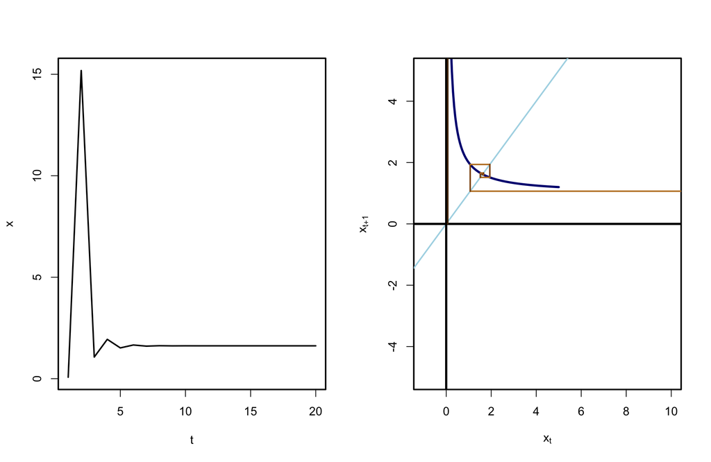

```r
q_map<-function(x_o=runif(1,0,1), N=20, burn_in=0,...)
{
  par(mfrow=c(1,2), lwd=2) #mar=c(4,4,1,2),
  ############# Trace #############
  x <- array(dim=N)
  x[1] <- x_o
  for(i in 2:N)
    #x[i]<-r*x[i-1]*(1-x[i-1])
    x[i]<-1+(1/x[i-1])

  plot(x[(burn_in+1):N], type='l', xlab='t', ylab='x',...)
  #################################

  ##########  Quadradic Map ########
  x<-seq(from=0,to=5,length.out=100)
  x_np1<-array(dim=100)
  for(i in 1:length(x))
    #x_np1[i]<-r*x[i]*(1-x[i])
    x_np1[i] <- 1+(1/x[i])

  plot(x, x_np1, type='l', col="navy", lwd=3, xlab=expression(x[t]), ylab=expression(x[t+1]), xlim=c(-1,10), ylim=c(-5,5))
  abline(0,1, col="lightblue")
  abline(h=0, v=0, lwd=3)

  start=x_o
  vert=FALSE
  lines( x=c(start,start), y=c(0,1+1/start), col=pal[1] )
  for(i in 1:(2*N))
  {
    if(vert)
    {
      lines( x=c(start,start), y=c(start,1+1/start), col=pal[2] )
      vert=FALSE
    }
    else
    {
      lines(x=c(start,
                1+1/start),
            y=c(1+1/start,
                1+1/start), col=pal[3] )
      vert=TRUE
      start=1+1/start
    }
  }
  #################################
}

q_map(r_o=0.4)
```

## Bifurcation plot

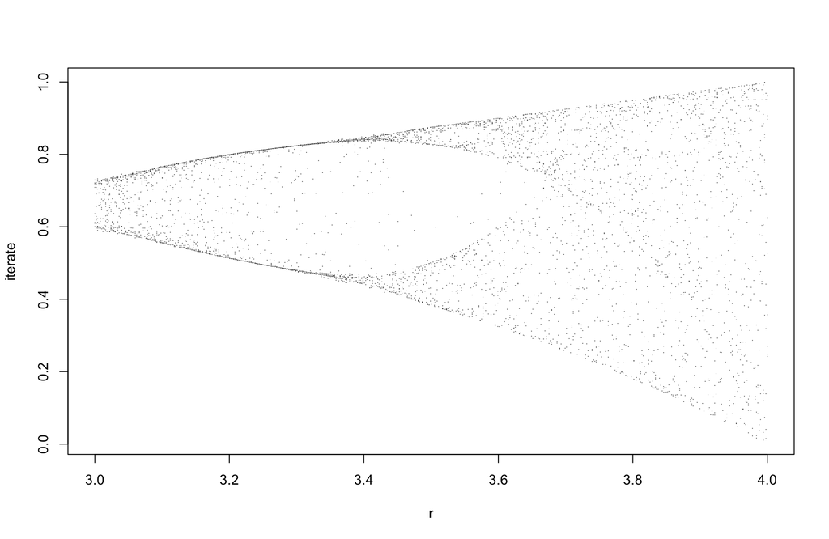

```r
library(parallel)
bifurcation <- function(from=3,to=4,res=500,
                      x_o=runif(1,0,1),N=10,reps=10,cores=4)
{
  r_s<-seq(from=from,to=to,length.out=res)
  r<-numeric(res*reps)
  for(i in 1:res)
    r[((i-1)*reps+1):(i*reps)]<-r_s[i]

  x<-array(dim=N)

  iterate<-mclapply(1:(res*reps),
                    mc.cores=cores,
                    function(k){
                      x[1]<-runif(1,0,1)
                      for(i in 2:N)
                        x[i]<-r[k]*x[i-1]*(1-x[i-1])

                      return(x[N])
                    })

  plot(r,iterate,pch=15,cex=0.1)

  return(cbind(r,iterate))
}

#warning: Even in parallel with 4 cores, this is by no means fast code!
bi<-bifurcation()
```

```r
#png('chaos.png',width=1000,height=850)
#par(bg='black',col='green',col.main='green',cex=1)
#plot(bi,col='green',xlab='R',ylab='n --> inf',main='',pch=15,cex=0.2)
#dev.off()
```